# TP Econometría

2025-11-03

# Set-up

```r
library(wooldridge)
library(ggplot2)
```

# meap93

Este conjunto de datos contiene información sobre los resultados académicos y los recursos de las escuelas secundarias en el estado de Michigan, EE. UU., durante el año 1993.

El dataset fue recopilado por el Departamento de Educación de Michigan. El objetivo principal suele ser analizar cómo los recursos de la escuela (como el gasto por alumno o el salario de los profesores) y las características demográficas de los estudiantes (como el porcentaje en programas de almuerzo) afectan los resultados académicos (tasas de graduación y aprobación de exámenes).

El archivo contiene 408 observaciones (una por cada escuela) y 17 variables (columnas).

## Descripción de las Variables:

- lnchprg: Porcentaje de estudiantes en el “programa de almuerzos escolares” (un indicador común de la situación socioeconómica de los estudiantes, son como becas para almorzar).
- enroll: Matrícula escolar (cantidad total de estudiantes inscriptos en la escuela).
- staff: Personal total por cada 1000 estudiantes (esto incluye profesores, administrativos, etc.).
- expend: Gasto por estudiante, medido en dólares ($).
- salary: Salario promedio de los profesores, medido en dólares ($).
- benefits: Beneficios promedio de los profesores, medidos en dólares ($) (ej. seguro médico).
- droprate: Tasa de deserción escolar (abandono), expresada en porcentaje).
- gradrate: Tasa de graduación escolar, expresada en porcentaje.
- math10: Porcentaje de estudiantes que aprobaron el examen MEAP de matemáticas de 10º grado (aprox tercer año de CABA). (MEAP es el examen estandarizado de evaluación de Michigan).
- sci11: Porcentaje de estudiantes que aprobaron el examen MEAP de ciencias de 11º grado (aprox cuarto año de CABA).
- totcomp: Compensación total promedio del profesor (es la suma de salary + benefits).
- ltotcomp: Logaritmo natural de la compensación total ( log(totcomp) ).
- lexpend: Logaritmo natural del gasto por estudiante ( log(expend) ).
- lenroll: Logaritmo natural de la matrícula escolar ( log(enroll) ).
- lstaff: Logaritmo natural del personal ( log(staff) ).
- bensal: Ratio o proporción entre beneficios y salario (calculado como benefits / salary).
- lsalary: Logaritmo natural del salario promedio ( log(salary) ).

Analisis: - Media, Varianza, etc. de cada una - Histogramas de cómo se distribuyen - Relación con las demas variables (matriz de correlación)

```r
data('meap93', package = 'wooldridge')
attach(meap93)
head(meap93)
```

```
##   lnchprg enroll staff expend salary benefits droprate gradrate math10 sci11
## 1     1.4   1862 112.6   5765  37498     7420      2.9     89.2   56.4  67.9
## 2     2.3  11355 101.2   6601  48722    10370      1.3     91.4   42.7  65.3
## 3     2.7   7685 114.0   6834  44541     7313      3.5     91.4   43.8  54.3
## 4     3.4   1148  85.4   3586  31566     5989      3.6     86.6   25.3  60.0
## 5     3.4   1572  96.1   3847  29781     5545      0.0    100.0   15.3  65.8
## 6     3.4   2496 101.1   5070  36801     5895      2.7     89.2   46.0  60.5
##   totcomp ltotcomp  lexpend  lenroll   lstaff    bensal  lsalary
## 1   44918 10.71259 8.659560 7.529407 4.723842 0.1978772 10.53204
## 2   59092 10.98685 8.794976 9.337414 4.617099 0.2128402 10.79389
## 3   51854 10.85619 8.829665 8.947025 4.736198 0.1641858 10.70417
## 4   37555 10.53356 8.184793 7.045776 4.447346 0.1897295 10.35984
## 5   35326 10.47237 8.255049 7.360104 4.565389 0.1861925 10.30163
## 6   42696 10.66186 8.531096 7.822445 4.616110 0.1601859 10.51328
```

```r
summary(meap93)
```

```
##     lnchprg          enroll          staff            expend
##  Min.   : 1.40   Min.   :  212   Min.   : 65.90   Min.   :3332
##  1st Qu.:14.62   1st Qu.: 1038   1st Qu.: 91.45   1st Qu.:3821
##  Median :23.85   Median : 1840   Median : 99.00   Median :4145
##  Mean   :25.20   Mean   : 2664   Mean   :100.64   Mean   :4377
##  3rd Qu.:33.83   3rd Qu.: 3085   3rd Qu.:108.03   3rd Qu.:4659
##  Max.   :79.50   Max.   :16793   Max.   :166.60   Max.   :7419
##      salary         benefits        droprate         gradrate
##  Min.   :19764   Min.   :    0   Min.   : 0.000   Min.   : 23.50
##  1st Qu.:28186   1st Qu.: 5536   1st Qu.: 1.900   1st Qu.: 77.00
##  Median :31266   Median : 6304   Median : 3.700   Median : 86.30
##  Mean   :31775   Mean   : 6463   Mean   : 5.066   Mean   : 83.65
##  3rd Qu.:34500   3rd Qu.: 7228   3rd Qu.: 6.500   3rd Qu.: 93.22
##  Max.   :52812   Max.   :11618   Max.   :61.900   Max.   :127.10
##      math10          sci11          totcomp         ltotcomp
##  Min.   : 1.90   Min.   : 7.20   Min.   :24498   Min.   :10.11
##  1st Qu.:16.62   1st Qu.:41.30   1st Qu.:34032   1st Qu.:10.44
##  Median :23.40   Median :49.10   Median :37444   Median :10.53
##  Mean   :24.11   Mean   :49.18   Mean   :38238   Mean   :10.54
##  3rd Qu.:30.05   3rd Qu.:57.15   3rd Qu.:41637   3rd Qu.:10.64
##  Max.   :66.70   Max.   :85.70   Max.   :63518   Max.   :11.06
##     lexpend         lenroll          lstaff          bensal
##  Min.   :8.111   Min.   :5.357   Min.   :4.188   Min.   :0.0000
##  1st Qu.:8.248   1st Qu.:6.945   1st Qu.:4.516   1st Qu.:0.1880
##  Median :8.330   Median :7.518   Median :4.595   Median :0.2024
##  Mean   :8.370   Mean   :7.510   Mean   :4.603   Mean   :0.2045
##  3rd Qu.:8.447   3rd Qu.:8.034   3rd Qu.:4.682   3rd Qu.:0.2203
##  Max.   :8.912   Max.   :9.729   Max.   :5.116   Max.   :0.4500
##     lsalary
##  Min.   : 9.892
##  1st Qu.:10.247
##  Median :10.350
##  Mean   :10.354
##  3rd Qu.:10.449
##  Max.   :10.874
```

Qué nos dice esto? (además de lo obvio, varias metricas descriptivas de cada variable). Tenemos algunos datos que son porcentajes, otros que son proporciones cada 1000 y otras son dinero (y ni hablar de los logaritmos); por lo que sería conveniente estandarizar las variables (y que así la escala no sea un problema a la hora de interpretar los coeficientes).

```
## [1] "lnchprg"
```

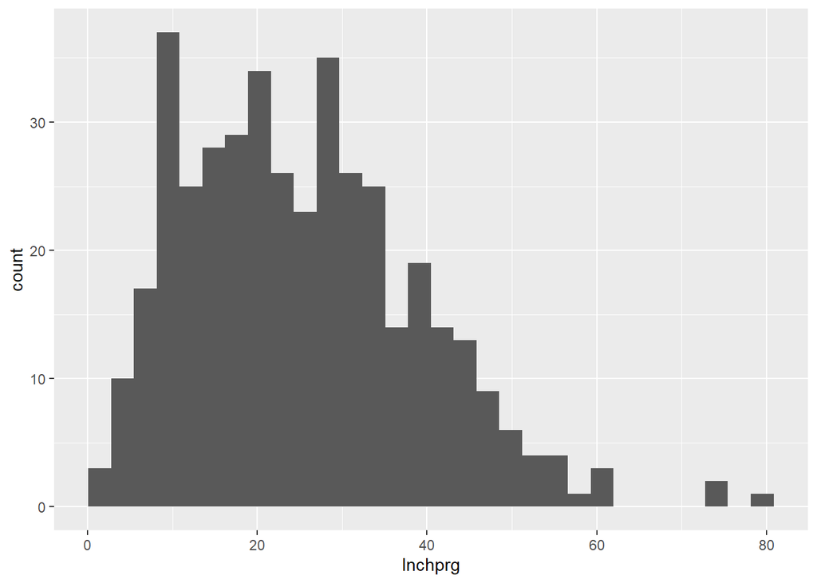

```
## [1] "enroll"
```

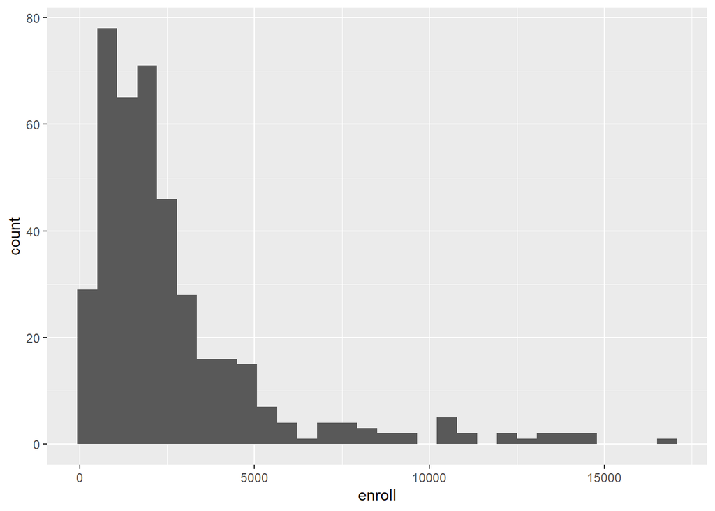

```
## [1] "staff"
```

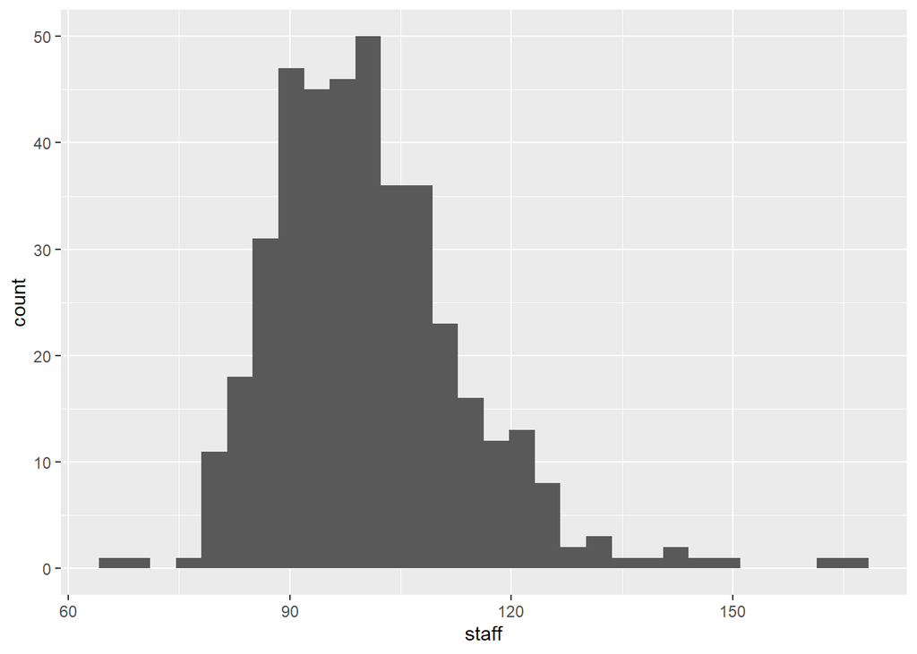

```
## [1] "expend"
```

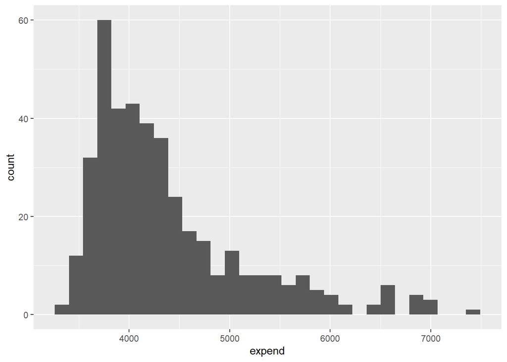

```
## [1] "salary"
```

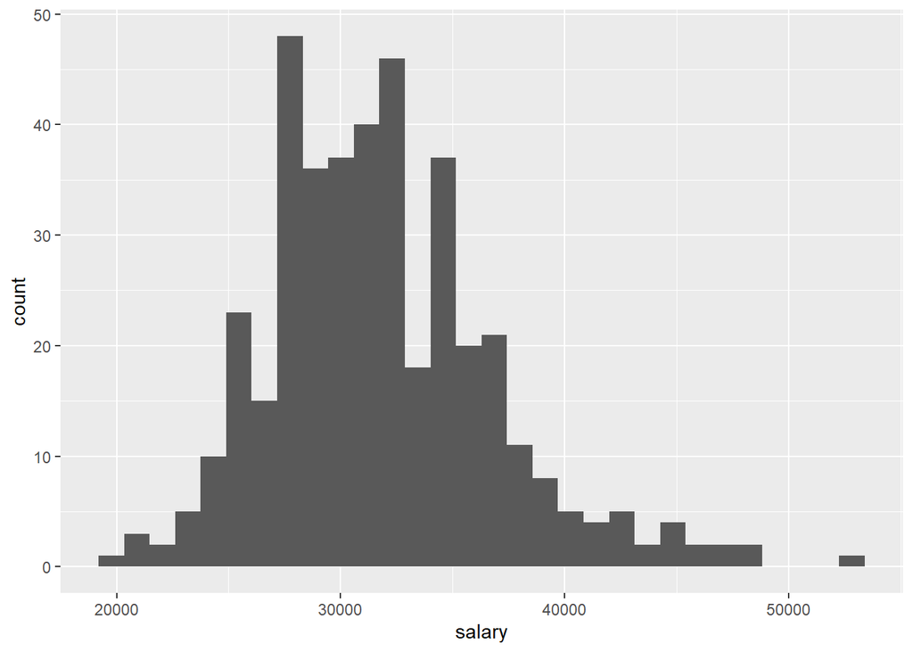

```
## [1] "benefits"
```

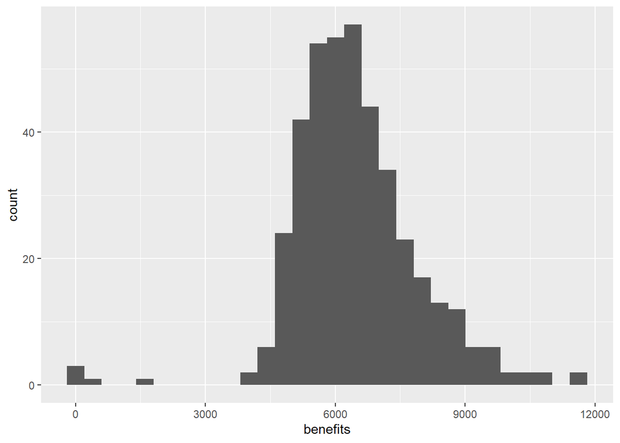

```
## [1] "droprate"
```

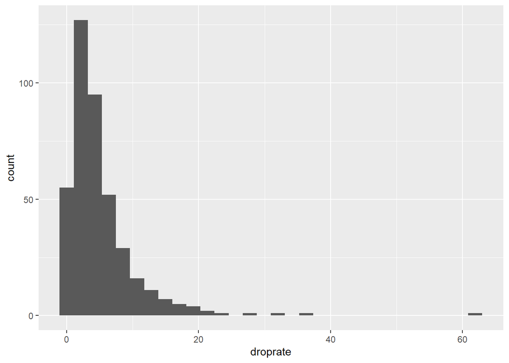

```
## [1] "gradrate"
```

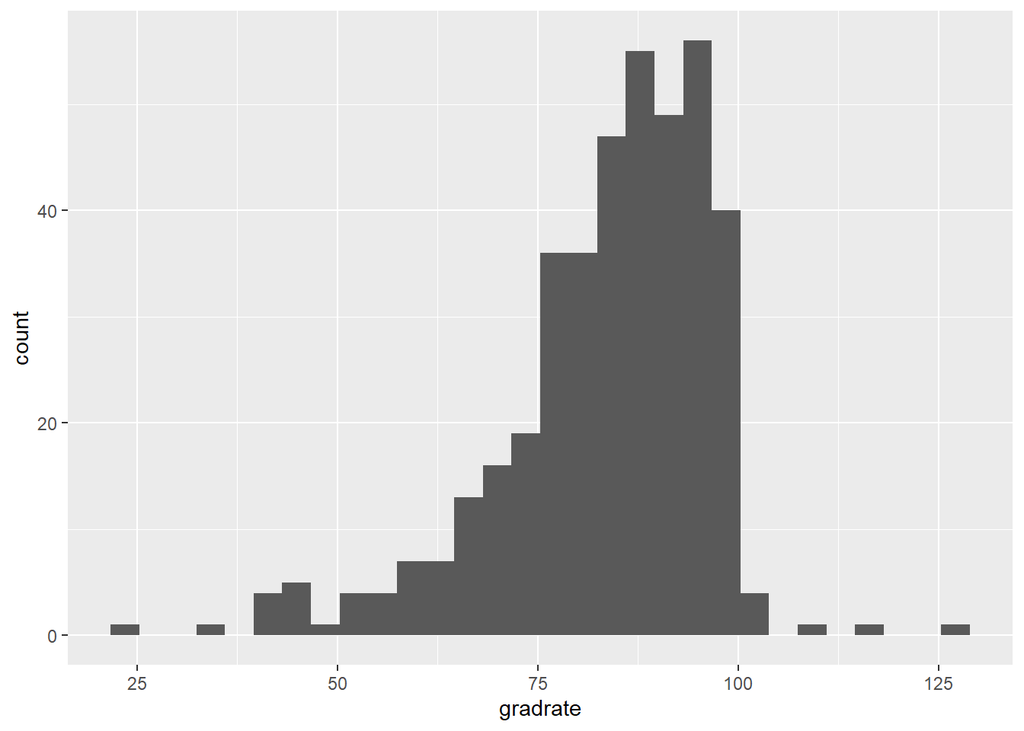

```
## [1] "math10"
```

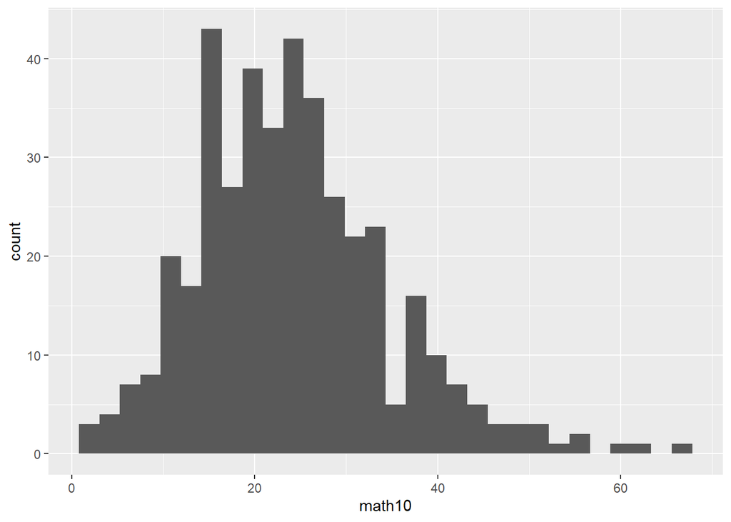

```
## [1] "sci11"
```

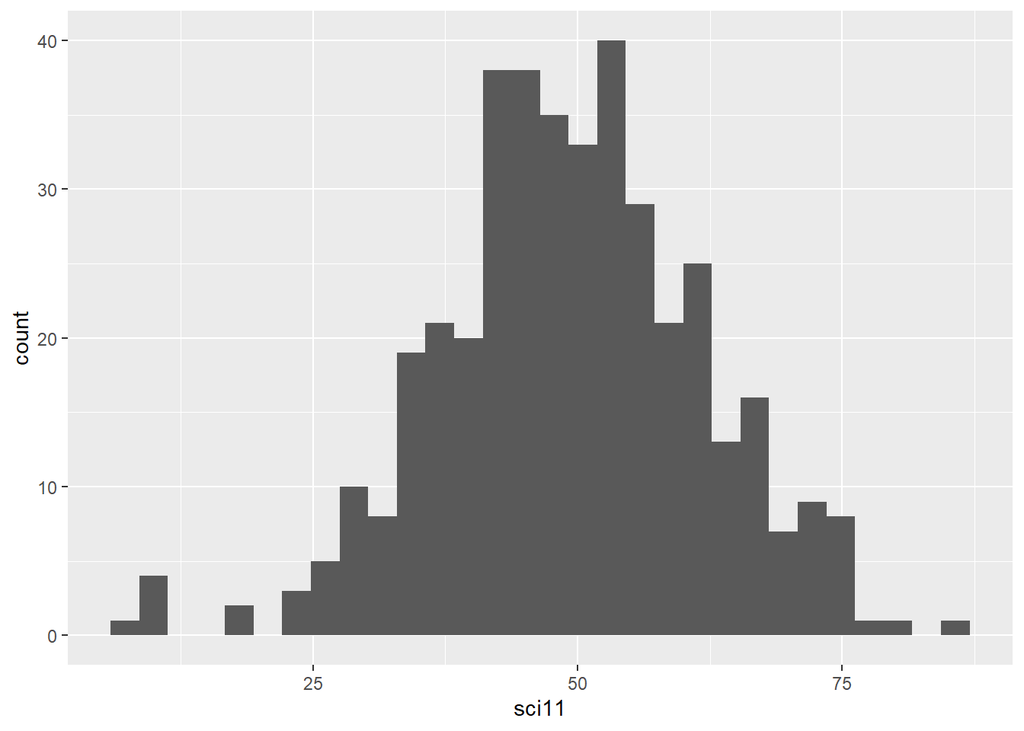

```
## [1] "totcomp"
```

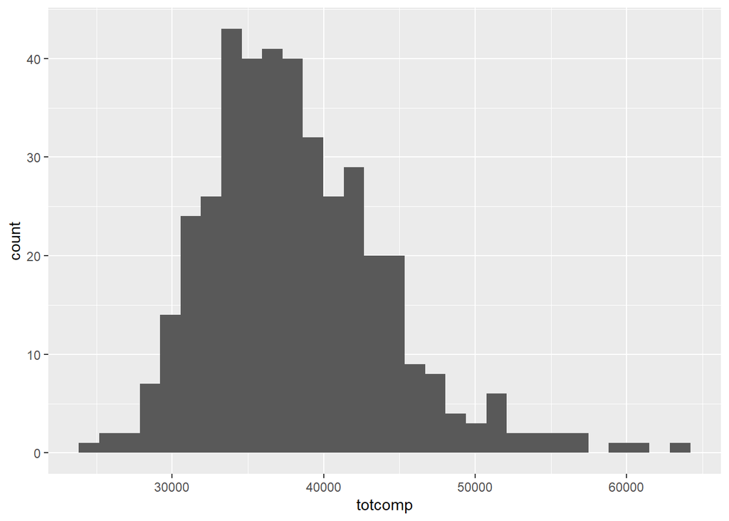

```
## [1] "ltotcomp"
```

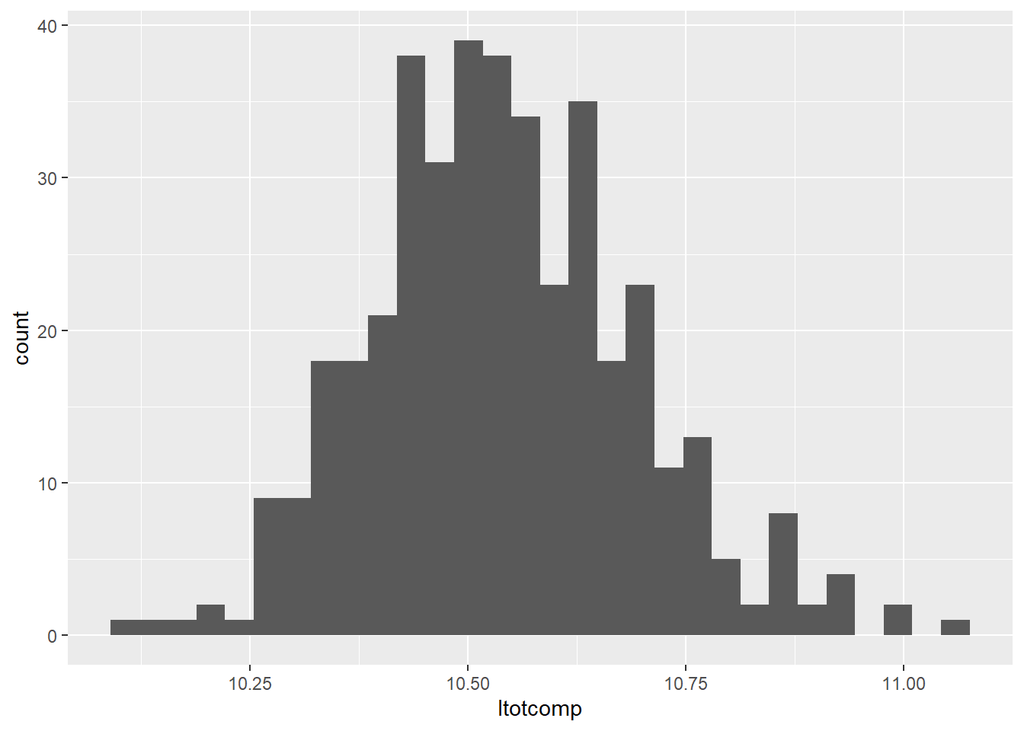

```
## [1] "lexpend"
```

[5 more figures not shown]

```r
for(col in colnames(meap93)){
  print(col)

  p <- ggplot(meap93, aes(x=.data[[col]]))+
    geom_histogram()

  print(p)
}
```